# Stitch

Stitch is a small python library for writing reproducible reports in markdown. It's heavily inspired by (read: a python clone of) [knitr](http://yihui.name/knitr/) and [RMarkdown](http://rmarkdown.rstudio.com).

You might want to consider [Knitpy](https://github.com/janschulz/knitpy) instead of stitch. It's been around longer is probably more usable at this point.

This document shows you the source markdown side-by-side with the executed and rendered HTML. For more a more complex example, check out the "Examples" tab in the navbar, which links to the source markdown and rendered HTML, PDF, and docx versions of the document.

## Code-Chunks

````
The syntax for creating an executable block is

    ```{kernel_name}
    # Your code here
    ```

The output of that block, if any, will be inserted just after the end of the
code block[^literal_code].

[^literal_code]: If you look at the markdown source for this document,
you'll see that I've indented the code block by 4 spaces. This is so that
the block is interpreted as a literal chunk of text, and isn't intercepted
by the engine for execution. To actually run code the code chunk should be at
the start of the line.

Code chunks can accept up to two positional arguments

- `kernel_name` (required)
  See `jupyter-kernelspect list` for a list of the kernels installed on your
  system
- `chunk_name` (optional)
  And identifier for the code chunk. Used in several places for
  naming figures and files

And some keyword arguments

- `echo`
- `eval`
- `include`

The rest of this document is intended to demonstrate `stitch` in action.
````

The syntax for creating an executable block is

````
```{kernel_name}
# Your code here
```
````

The output of that block, if any, will be inserted just after the end of the code block[^1].

Code chunks can accept up to two positional arguments

- `kernel_name` (required) See `jupyter-kernelspect list` for a list of the kernels installed on your system
- `chunk_name` (optional) And identifier for the code chunk. Used in several places for naming figures and files

And some keyword arguments

- `echo`
- `eval`
- `include`

The rest of this document is intended to demonstrate `stitch` in action.

## Basics

````
`stitch` keeps a registry of kernels, meaning state is preserved between
code chunks

```{python}
x = 10
```


There was no output there, but we can reuse `x` now

```{python}
print(x + 2)
```

Now we see the output.
````

`stitch` keeps a registry of kernels, meaning state is preserved between code chunks

```python
In [1]: x = 10
```

There was no output there, but we can reuse `x` now

```python
In [2]: print(x + 2)
```

```
12
```

Now we see the output.

## Options

````
You can exclude the code, but include the output with the `echo=False` option

For example, we can show the fibbonnaci numbers less than 100, without
bothering the reader with how we calculate them:

```{python, echo=False}
def fib(n):
    a, b = 0, 1
    while a < n:
        print(a, end=', ')
        a, b = b, a+b

fib(100)
```
````

You can exclude the code, but include the output with the `echo=False` option

For example, we can show the fibbonnaci numbers less than 100, without bothering the reader with how we calculate them:

```
0, 1, 1, 2, 3, 5, 8, 13, 21, 34, 55, 89,
```

## Exceptions

````
By default, exceptions are displayed and the stitching continues

```{python}
raise ValueError("ValueError!")
```
````

By default, exceptions are displayed and the stitching continues

```python
In [4]: raise ValueError("ValueError!")
```

```
---------------------------------------------------------------------------
ValueError                                Traceback (most recent call last)
<ipython-input-4-0dec59cd0416> in <module>()
----> 1 raise ValueError("ValueError!")

ValueError: ValueError!
```

## Rich Display

````
We reuse IPython's rich display system, so objects defining `_repr_html_`,
`_repr_latex_`, etc. will have that represented in the output.
Pandas DataFrames, for example, do so

```{python}
import pandas as pd
pd.options.display.latex.repr = True
import seaborn as sns
df = sns.load_dataset("iris")
df.head()
```
````

We reuse IPython's rich display system, so objects defining `_repr_html_`, `_repr_latex_`, etc. will have that represented in the output. Pandas DataFrames, for example, do so

```python
In [5]: import pandas as pd
   ...: pd.options.display.latex.repr = True
   ...: import seaborn as sns
   ...: df = sns.load_dataset("iris")
   ...: df.head()
```

|  | sepal_length | sepal_width | petal_length | petal_width | species |
| --- | --- | --- | --- | --- | --- |
| 0 | 5.1 | 3.5 | 1.4 | 0.2 | setosa |
| 1 | 4.9 | 3.0 | 1.4 | 0.2 | setosa |
| 2 | 4.7 | 3.2 | 1.3 | 0.2 | setosa |
| 3 | 4.6 | 3.1 | 1.5 | 0.2 | setosa |
| 4 | 5.0 | 3.6 | 1.4 | 0.2 | setosa |

## Graphics

````
It's possible to capture rich output, like graphics


```{python}
%matplotlib inline

sns.set()
sns.pairplot(df, hue="species");
```

You can control image attributes from the chunk options

```{python, width=80, height=80px}
%matplotlib inline

sns.set()
sns.pairplot(df, hue="species");
```
````

It's possible to capture rich output, like graphics

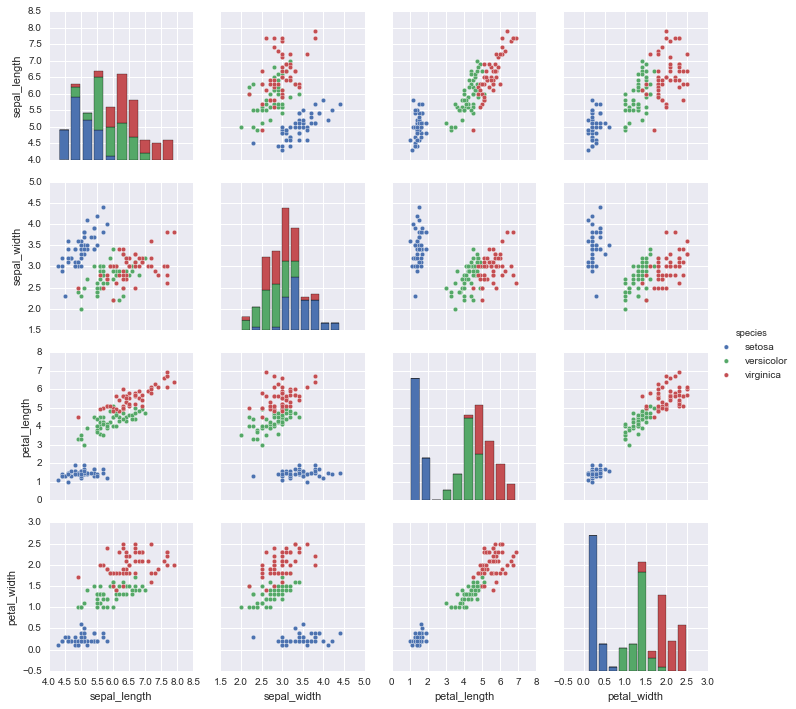

```python
In [6]: %matplotlib inline
   ...:
   ...: sns.set()
   ...: sns.pairplot(df, hue="species");
```

You can control image attributes from the chunk options

```python
In [7]: %matplotlib inline
   ...:
   ...: sns.set()
   ...: sns.pairplot(df, hue="species");
```

[output not shown]

## Document Options

[output not shown]

You can provide document-wide options in a YAML metadata block at the start of the file. This looks like

````
```
header-includes:
    - \usepackage{booktabs}
```
````

## Command-line Interface

````
The command-line interface is as similar to pandoc's as possible.
The simplest example is just passing an input markdown file:

    ```
    knotr input.md
    ```

This will take the text in `input.md` execute it and convert it to HTML,
printing the result to stdout.

Other useful options are

- `-o` or `--output_file`: the file to write the stitched output to; defaults
to stdout.
- `-t` or `--to`: the type to transform to. Defaults to `html` or it's
inferred from the `--output_file` extension.

The biggest difference right now is the treatment of stdin.
With pandoc you can convert stdin with

    ```
    $ cat input.md | pandoc
    ```

With `stitch`, it's written as

    ```
    $ cat input.md | knotr -
    ```

So a `-` is the marker for stdin.
````

The command-line interface is as similar to pandoc's as possible. The simplest example is just passing an input markdown file:

````
```
knotr input.md
```
````

This will take the text in `input.md` execute it and convert it to HTML, printing the result to stdout.

Other useful options are

- `-o` or `--output_file`: the file to write the stitched output to; defaults to stdout.
- `-t` or `--to`: the type to transform to. Defaults to `html` or it's inferred from the `--output_file` extension.

The biggest difference right now is the treatment of stdin. With pandoc you can convert stdin with

````
```
$ cat input.md | pandoc
```
````

With `stitch`, it's written as

````
```
$ cat input.md | knotr -
```
````

So a `-` is the marker for stdin.

## Notes on Pandoc

[output not shown]

If you aren't familiar, pandoc is a universal document converter written in Haskell.

For outputs like HTML and LaTeX, pandoc produces document fragments by default. This means the converted output doesn't include things like `<head>` tags, just the body. `stitch`, on the other hand, prefers standalone documents.

The second difference is that stitch prefers self-contained documents. This means things like images are inlined as base64 encoded PNGs or SVGs. With pandoc, this options are enabled with the

- `--standalone`
- `--self-contained`

options. With `stitch`, the defaults are flipped to True, and disabled with

- `--no-standalone`
- `--no-self-contained`
[^1]: If you look at the markdown source for this document, you'll see that I've indented the code block by 4 spaces. This is so that the block is interpreted as a literal chunk of text, and isn't intercepted by the engine for execution. To actually run code the code chunk should be at the start of the line.